# Mini project

Q 1) Which are the movies with third lowest and third highest budget?

```python
# To find the 3rd highest and lowest budget movie.
# we have to make sure that the movie with budget ZERO does not affect the result.
# so change the zero into NAN in 'budget' column.
```

```python
df['budget']=df['budget'].replace(0,np.NAN)
```

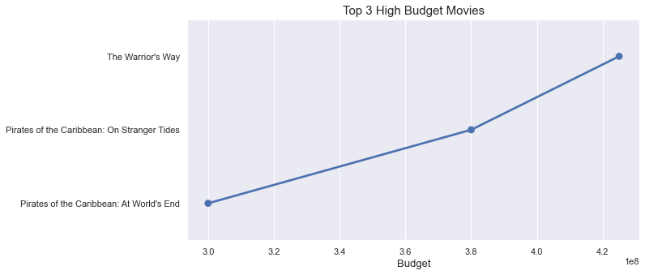

```python
info = pd.DataFrame(df['budget'].sort_values(ascending = False))
info['original_title'] = df['original_title']
data = list(map(str,(info['original_title'])))

#extract the top 3 budget movies data from the list and dataframe.
x = list(data[:3])
y = list(info['budget'][:3])

#plot the figure and setup the title and labels.
ax = sns.pointplot(x=y,y=x)
sns.set(rc={'figure.figsize':(10,5)})
ax.set_title("Top 3 High Budget Movies",fontsize = 15)
ax.set_xlabel("Budget",fontsize = 13)
sns.set_style("darkgrid")
```

```python
# In the above plot we can top High budget movies and they are...
# 1. The Warrior's way.
# 2. Pirates of the Caribbean: On Stranger Tides.
# 3. Pirates of the Caribbean: At world's End.
```

```python
# similarly for the third lowest budget movie the below code is written
```

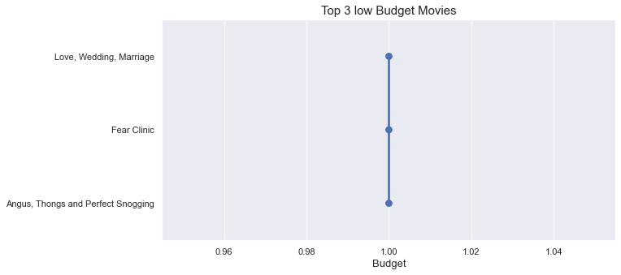

```python
info1 = pd.DataFrame(df['budget'].sort_values())
info1['original_title'] = df['original_title']
data = list(map(str,(info1['original_title'])))

#extract the top 3 budget movies data from the list and dataframe.
x = list(data[:3])
y = list(info1['budget'][:3])

#plot the figure and setup the title and labels.
ax = sns.pointplot(x=y,y=x)
sns.set(rc={'figure.figsize':(10,5)})
ax.set_title("Top 3 low Budget Movies",fontsize = 15)
ax.set_xlabel("Budget",fontsize = 13)
sns.set_style("darkgrid")
```

```python
# In the above plot we can top Low budget movies and they are...
# 1. Love, Wedding, Marriage.
# 2. Fear Clinic.
# 3. Angus, Thongs and Perfect Snogging.
```

The answers are:

The third highest budget movie in data set is "Pirates of the Caribbean: At world's End".

The third lowest budget movie in data set is "Angus, Thongs and Perfect Snogging".

```python
###----------------------------------###
```

Q 2) What is the average number of words in movie titles between the year 2000-2005?

```python
# firstly we will make a new data set 'df_years',
# And only add the movies which were released between 2000-2005.
```

```python
df_years=df[df['release_year']>=2000]
```

```python
df_years=df_years[df_years['release_year']<=2005]
```

```python
df_years=df_years.sort_values('release_year')
```

```python
df_years.head()
```

[output not shown]

```python
df_years.shape
```

```
(1663, 15)
```

```python
# Now the 'df_years' contains only movies which were released between 2000-2005.
```

```python
df_years['word_count'] = df_years['original_title'].str.split().map(len)
```

```python
# I have added a new column called word_count
```

```python
df_years.info()
```

```
<class 'pandas.core.frame.DataFrame'>
Int64Index: 1663 entries, 8887 to 6246
Data columns (total 16 columns):
 #   Column          Non-Null Count  Dtype
---  ------          --------------  -----
 0   id              1663 non-null   int64
 1   imdb_id         1663 non-null   object
 2   popularity      1663 non-null   float64
 3   budget          993 non-null    float64
 4   revenue         1663 non-null   int64
 5   original_title  1663 non-null   object
 6   cast            1659 non-null   object
 7   director        1663 non-null   object
 8   overview        1663 non-null   object
 9   runtime         1663 non-null   int64
 10  genres          1661 non-null   object
 11  release_date    1663 non-null   object
 12  vote_count      1663 non-null   int64
 13  vote_average    1663 non-null   float64
 14  release_year    1663 non-null   int64
 15  word_count      1663 non-null   int64
dtypes: float64(3), int64(6), object(7)
memory usage: 220.9+ KB
```

```python
# In the above o/p we can see that a 15th column 'word_count' is been added.
# which contains the count of the number of words from the column 'original_title'.
```

```python
# Question was find average number of words in movie titles between the year 2000-2005.
# So we take mean in 'word_count' column and obtain the answer.
```

```python
# A plot of each year is shown below.
```

[figure not shown]

```python
sns.boxplot(x='release_year',y='word_count',data=df_years,palette='colorblind')
plt.title('Average no. of words in movies from 2000-2006')

plt.xlabel('Year')
plt.ylabel('No. of words')
plt.show()
```

```python
df_years['word_count'].mean()
```

```
2.8749248346361997
```

Answer to average number of words in movie titles between the year 2000-2005 is...

2.8749248346361997...(approximately = 3)

```python
###----------------------------------###-------------------------------------------###
```

Q 3) What is the most common genre for Vin Diesel and Emma Watson movies?

```python
# we will make two new data sets.
# One which is related to Vin Diesel,
# and other which is related to Emma Watson.
```

```python
search_strings=['Vin Diesel']
search_strings2=['Emma Watson']
```

```python
df_cast=df
```

```python
df_cast=df_cast[df_cast['cast'].notna()]
```

```python
df_cast_vin=df_cast[df_cast['cast'].str.contains('|'.join(search_strings) )]
df_cast_emma=df_cast[df_cast['cast'].str.contains('|'.join(search_strings2) )]
```

```python
df_cast_vin.shape
```

```
(20, 15)
```

```python
df_cast_emma.shape
```

```
(14, 15)
```

```python
# we can see that, Total no. movies acted by 'Vin Diesel' in our data set is 20.
# And, Total no. movies acted by 'Emma watson' in our data set is 14.
```

```python
df_cast_vin=df_cast_vin.drop(columns=['id','imdb_id','popularity','budget','revenue','vote_count','vote_average',
                              'overview','release_year'])
```

```python
df_cast_emma=df_cast_emma.drop(columns=['id','imdb_id','popularity','budget','revenue','vote_count','vote_average',
                              'overview','release_year'])
```

```python
# we have removed the unwanted columns from the data set
```

```python
dg_v=df_cast_vin['genres'].str.get_dummies(sep='|')
dg_v1= dg_v.sum().reset_index()
```

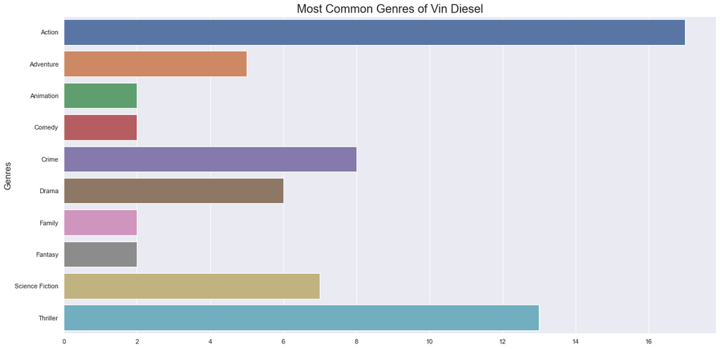

```python
plt.figure(figsize=(20,10))
sns.barplot(y=dg_v.columns,x=dg_v.sum(),data=dg_v1)
plt.title('Most Common Genres of Vin Diesel',fontsize=20)
plt.ylabel('Genres',fontsize=15)
plt.xlabel('')
#plt.xticks(rotation=90)
plt.show()
```

```python
# In the above plot we can see that most common genre of 'Vin diesel' is 'Action'.
```

```python
dg_e=df_cast_emma['genres'].str.get_dummies(sep='|')
dg_e1= dg_v.sum().reset_index()
```

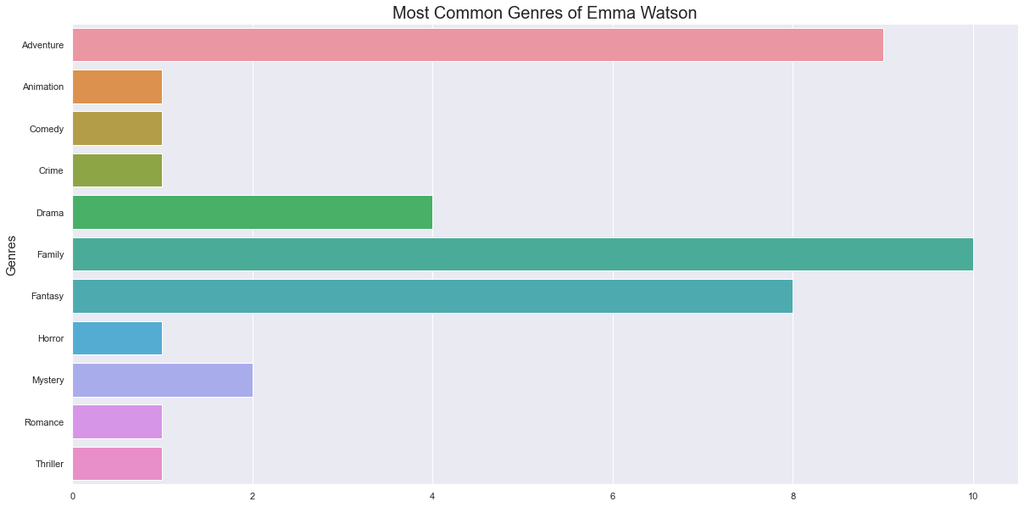

```python
plt.figure(figsize=(20,10))
sns.barplot(y=dg_e.columns,x=dg_e.sum(),data=dg_e1)
plt.title('Most Common Genres of Emma Watson',fontsize=20)
plt.ylabel('Genres',fontsize=15)
plt.xlabel('')
#plt.xticks(rotation=90)
plt.show()
```

```python
# In the above plot we can see that most common genre of 'Emma Watson' is 'Family'.
```

The answers are:

The most common genre of 'Vin diesel' is 'Action'.

The most common genre of 'Emma Watson' is 'Family'.

```python
###----------------------------------###-------------------------------------------------###
```

Q 4) Which are the movies with most and least earned revenue?

```python
df[df['revenue']>0].shape
```

```
(4850, 15)
```

```python
# In the above o/p we can see that there are only 4850 rows with revenue > 0.
# we have to make sure that the movie with revenue ZERO does not affect the result.
# so change the zero into NAN in 'revenue' column.
```

```python
df['revenue']=df['revenue'].replace(0,np.NAN)
```

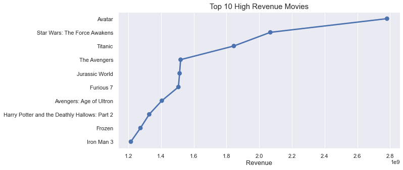

```python
info3 = pd.DataFrame(df['revenue'].sort_values(ascending = False))
info3['original_title'] = df['original_title']
data = list(map(str,(info3['original_title'])))

#extract the top 3 budget movies data from the list and dataframe.
x = list(data[:10])
y = list(info3['revenue'][:10])

#plot the figure and setup the title and labels.
ax = sns.pointplot(x=y,y=x)
sns.set(rc={'figure.figsize':(10,5)})
ax.set_title("Top 10 High Revenue Movies",fontsize = 15)
ax.set_xlabel("Revenue",fontsize = 13)
sns.set_style("darkgrid")
```

```python
# In the above plot we can see that the most revenue movie in our data set is 'Avatar'
```

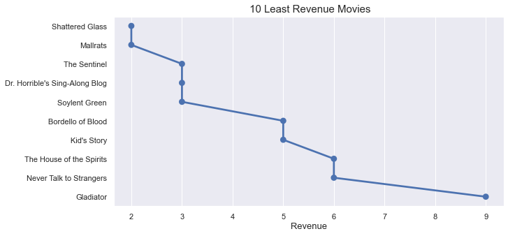

```python
info4 = pd.DataFrame(df['revenue'].sort_values(ascending = True))
info4['original_title'] = df['original_title']
data = list(map(str,(info4['original_title'])))

#extract the top 3 budget movies data from the list and dataframe.
x = list(data[:10])
y = list(info4['revenue'][:10])

#plot the figure and setup the title and labels.
ax = sns.pointplot(x=y,y=x)
sns.set(rc={'figure.figsize':(10,5)})
ax.set_title(" 10 Least Revenue Movies",fontsize = 15)
ax.set_xlabel("Revenue",fontsize = 13)
sns.set_style("darkgrid")
```

```python
# In the above plot we can see that the least revenue movie in our data set is 'Shattered Glass'
```

Answers are:

Most earned revenue movie is ' Avatar '.

Least earned revenue movie is ' Shattered Glass '.

```python
###----------------------------------###-------------------------------------------------###
```

Q 5) What is the average runtime of movies in the year 2006?

```python
df_2006=df[df['release_year']==2006]
```

```python
df_2006.columns
```

[output not shown]

```python
# removing unwanted columnns.
```

```python
df_2006=df_2006[['id', 'runtime',  'release_date', 'release_year']]
```

```python
df_2006.reset_index()
```

|  | index | id | runtime | release_date | release_year |
| --- | --- | --- | --- | --- | --- |
| 0 | 6554 | 834 | 106 | 1/12/06 | 2006 |
| 1 | 6555 | 58 | 151 | 6/20/06 | 2006 |
| 2 | 6556 | 920 | 117 | 6/8/06 | 2006 |
| 3 | 6557 | 36557 | 144 | 11/14/06 | 2006 |
| 4 | 6558 | 591 | 149 | 5/17/06 | 2006 |
| ... | ... | ... | ... | ... | ... |
| 397 | 6957 | 286 | 107 | 10/3/06 | 2006 |
| 398 | 6958 | 33753 | 100 | 3/1/06 | 2006 |
| 399 | 6959 | 24115 | 98 | 1/1/06 | 2006 |
| 400 | 6960 | 20605 | 92 | 5/25/06 | 2006 |
| 401 | 6961 | 15412 | 135 | 9/22/06 | 2006 |

402 rows × 5 columns

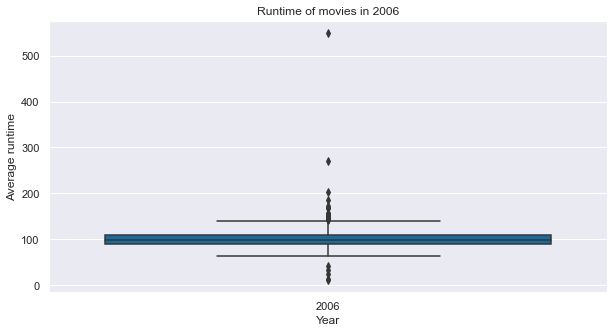

```python
sns.boxplot(x='release_year',y='runtime',data=df_2006,palette='colorblind')
plt.title('Runtime of movies in 2006')

plt.xlabel('Year')
plt.ylabel('Average runtime')
plt.show()
```

```python
df_2006['runtime'].mean()
```

```
103.12935323383084
```

Answer to average runtime of movies in the year 20006 is...

103.12935323383084 minutes.